# Homework 6 - BSTA 522

Matthew Hoctor

2/13/2022

# Part B

Read paper 6b and report up to 5 bullet points. (Read the CQR model and its advantage, not technical details.)

- Unlike accelerated failure time (AFT) models, censored quantile regression (CQR) models do not require the assumption of a homogenious treatment effect (i.e. the assumption that patients of differing risks for the outcome in question are affected equally by the treatment).
- CQR coefficients have the same interpretation as AFT model coefficients; i.e. the model coefficients reflect the effect of each covariate on the $\tau$th quantile, where $\tau$ is the CDF of of the probability distribution of events over time.
- CQR provides more information than Cox models because it provides probability distributions for time-to-event for populations or individuals.
- Caveat: CQR can be confusing for those only familiar with Cox models, and SAS & R statistical packages do not have standard functions for ‘second-stage inferences’ (e.g. testing for constant coefficients over different quantiles); although the authors provide some R software on their website.
- Downside: currently the performance of the model is qualitatively evaluated by visually inspecting differences in estimated survival probability and expected survival probability. Development of a formal test is the next step in their research.

# Part C

Chap 7: #2, #9. (Hint for #2: assume the total (RSS + penalty) is a finite value, then think about the penalty term.)

## 7.2

### a

If we assume $\lambda \rightarrow \infty$ and $m = 0$, then we are placing an infinite penalty on the squared value of the $g(x)$, the function itself (i.e.the 0th derivative); thus no matter what the RSS term for $g(x)$ may be, $g(x) = 0$ in this case. This is the only scenario where the formula takes on a finite value for $\lambda \rightarrow \infty$ and $m = 0$, and is therefore the minimum.

### b

If we assume $\lambda \rightarrow \infty$ and $m = 1$, then we are placing an infinite penalty on the squared value of $g'(x)$, the slope of the function (i.e.the 1st derivative); thus the the slope must equal 0, and therefore $g(x) = c$ in this case. If we are to pick $c$ such that RSS is minimized we find that $g(x) = \hat{\beta_0}$, the estimated mean.

### c

If we assume $\lambda \rightarrow \infty$ and $m = 2$, then we are placing an infinite penalty on the squared value of $g''(x)$, the curvature of the function (i.e.the 2nd derivative); thus the the curvature must equal 0, and therefore $g(x) = \hat{\beta_1} \times x + \hat{\beta_0}$ in this case. If we pick parameters such that RSS is minimized we find that:

$$\hat{\beta_1} = \frac{\sum_{i=1}^n (x_i - \bar{x})(y_i - \bar{y})}{\sum_{i=1}^n (x_i - \bar{x})^2}$$

$$\hat{\beta_0} = \bar{y} - \hat{\beta_1} \bar{x}$$

### d

If we assume $\lambda \rightarrow \infty$ and $m = 3$, then we are placing an infinite penalty on the squared value of $g'''(x)$, the rate of change ofcurvature of the function (i.e.the 3rd derivative); thus the rate of change of the curvature must equal 0, and therefore $g(x) = \hat{\beta_0} + \hat{\beta_1} \times x + \hat{\beta_2} \times x^2$ in this case.

### e

If we assume $\lambda \rightarrow 0$ and $m = 3$, then we are placing an no penalty on the squared value of $g'''(x)$, the rate of change of curvature of the function (i.e.the 3rd derivative); thus $g(x)$ is completely unrestrained and may take on any form. Since $g(x)$ can have infinite flexibility the RSS term may be minimized to zero with an arbitrarily flexible function; e.g. if each $x_i$ is a unique value then RSS can be minimized to zero when $g(x)$ takes the form of a polynomial with degree equal to $n$.

## 7.9

This question uses the variables dis (the weighted mean of distances to five Boston employment centers) and nox (nitrogen oxides concentration in parts per 10 million) from the Boston data. We will treat dis as the predictor and nox as the response.

### Setup

Dataset specification

```r
boston <- Boston
```

### a

Use the poly() function to fit a cubic polynomial regression to predict nox using dis. Report the regression output, and plot the resulting data and polynomial fits.

```r
boston.fit0 <- lm(nox ~ poly(dis, 3),
                  data = boston)
summary(boston.fit0)
```

```
##
## Call:
## lm(formula = nox ~ poly(dis, 3), data = boston)
##
## Residuals:
##       Min        1Q    Median        3Q       Max
## -0.121130 -0.040619 -0.009738  0.023385  0.194904
##
## Coefficients:
##                Estimate Std. Error t value Pr(>|t|)
## (Intercept)    0.554695   0.002759 201.021  < 2e-16 ***
## poly(dis, 3)1 -2.003096   0.062071 -32.271  < 2e-16 ***
## poly(dis, 3)2  0.856330   0.062071  13.796  < 2e-16 ***
## poly(dis, 3)3 -0.318049   0.062071  -5.124 4.27e-07 ***
## ---
## Signif. codes:  0 '***' 0.001 '**' 0.01 '*' 0.05 '.' 0.1 ' ' 1
##
## Residual standard error: 0.06207 on 502 degrees of freedom
## Multiple R-squared:  0.7148, Adjusted R-squared:  0.7131
## F-statistic: 419.3 on 3 and 502 DF,  p-value: < 2.2e-16
```

We can use visualize this fit with the following plot:

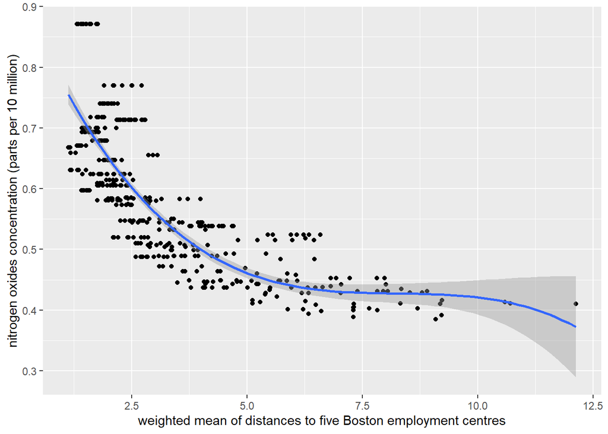

```r
ggplot(boston,
       aes(x = dis, y = nox)) +
          geom_point() +
          stat_smooth(method='lm', formula = y ~ poly(x,3), size = 1) +
          xlab('weighted mean of distances to five Boston employment centres') +
          ylab('nitrogen oxides concentration (parts per 10 million)')
```

### b

Plot the polynomial fits for a range of different polynomial degrees (say, from 1 to 10), and report the associated residual sum of squares.

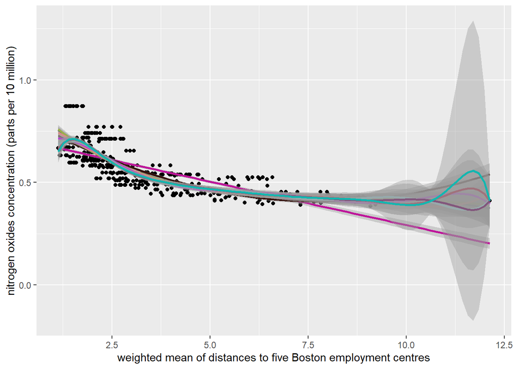

```r
ggplot(boston,
       aes(x = dis, y = nox)) +
          geom_point() +
          stat_smooth(method='lm', formula = y ~ poly(x,1), size = 1, colour = "#be149a") +
          stat_smooth(method='lm', formula = y ~ poly(x,2), size = 1, colour = "#330f09") +
          stat_smooth(method='lm', formula = y ~ poly(x,3), size = 1, colour = "#092d33") +
          stat_smooth(method='lm', formula = y ~ poly(x,4), size = 1, colour = "#9abe14") +
          stat_smooth(method='lm', formula = y ~ poly(x,5), size = 1, colour = "#f9877f") +
          stat_smooth(method='lm', formula = y ~ poly(x,6), size = 1, colour = "#c808f9") +
          stat_smooth(method='lm', formula = y ~ poly(x,7), size = 1, colour = "#8ee5ee") +
          stat_smooth(method='lm', formula = y ~ poly(x,8), size = 1, colour = "#ab2c49") +
          stat_smooth(method='lm', formula = y ~ poly(x,9), size = 1, colour = "#732a68") +
          stat_smooth(method='lm', formula = y ~ poly(x,10), size = 1, colour = "#12b7b0") +
          xlab('weighted mean of distances to five Boston employment centres') +
          ylab('nitrogen oxides concentration (parts per 10 million)')
```

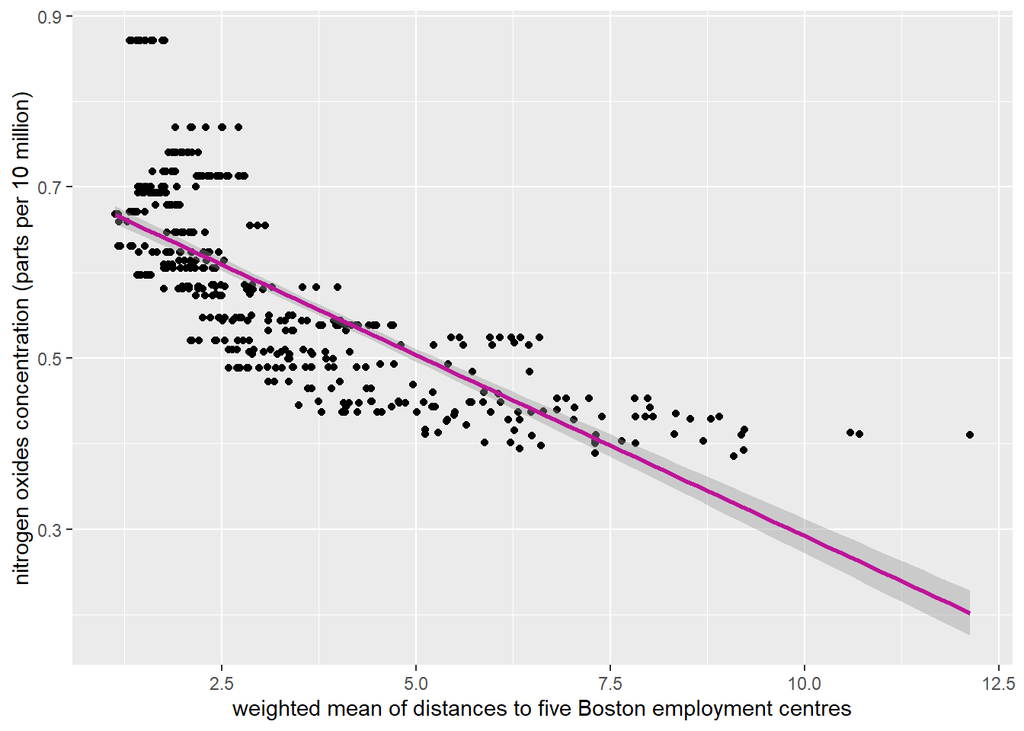

```r
ggplot(boston,
       aes(x = dis, y = nox)) +
          geom_point() +
          stat_smooth(method='lm', formula = y ~ poly(x,1), size = 1, colour = "#be149a") +
          xlab('weighted mean of distances to five Boston employment centres') +
          ylab('nitrogen oxides concentration (parts per 10 million)')
```

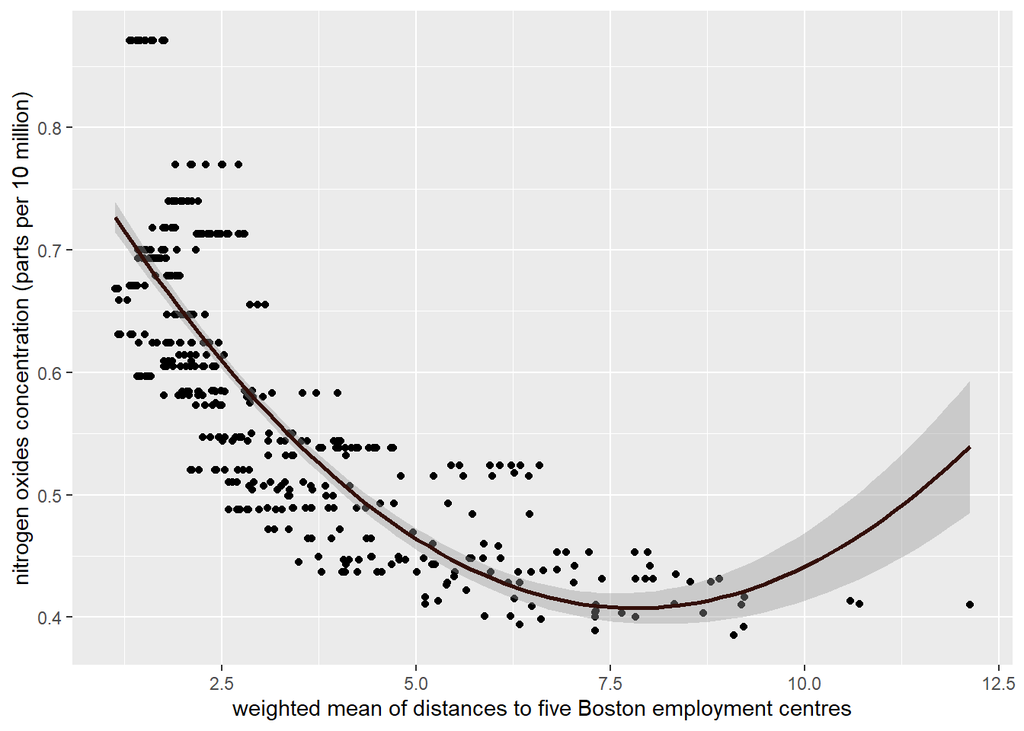

```r
ggplot(boston,
       aes(x = dis, y = nox)) +
          geom_point() +
          stat_smooth(method='lm', formula = y ~ poly(x,2), size = 1, colour = "#330f09") +
          xlab('weighted mean of distances to five Boston employment centres') +
          ylab('nitrogen oxides concentration (parts per 10 million)')
```

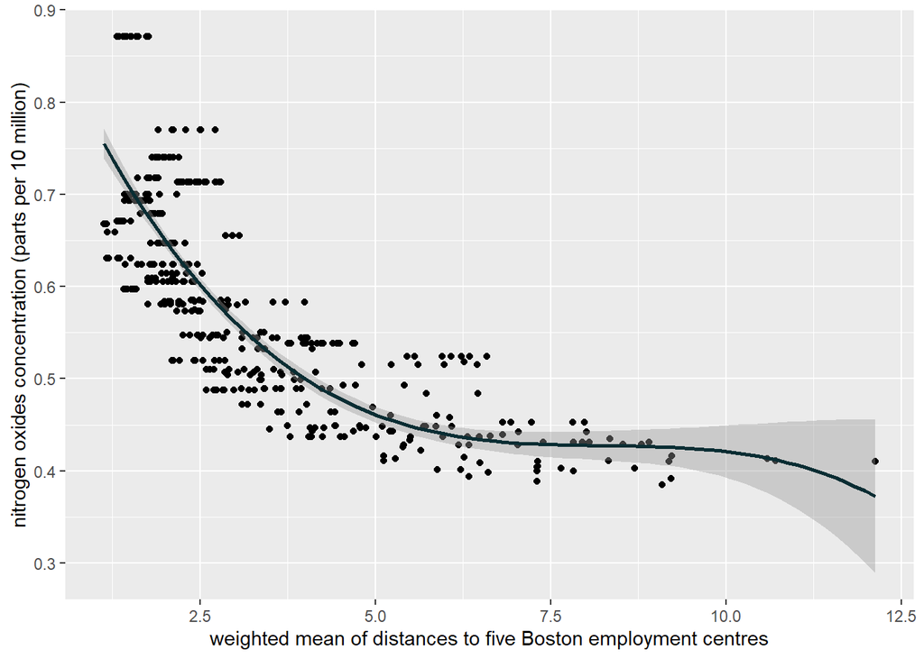

```r
ggplot(boston,
       aes(x = dis, y = nox)) +
          geom_point() +
          stat_smooth(method='lm', formula = y ~ poly(x,3), size = 1, colour = "#092d33") +
          xlab('weighted mean of distances to five Boston employment centres') +
          ylab('nitrogen oxides concentration (parts per 10 million)')
```

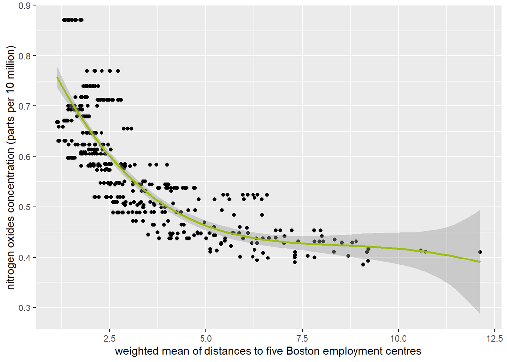

```r
ggplot(boston,
       aes(x = dis, y = nox)) +
          geom_point() +
          stat_smooth(method='lm', formula = y ~ poly(x,4), size = 1, colour = "#9abe14") +
          xlab('weighted mean of distances to five Boston employment centres') +
          ylab('nitrogen oxides concentration (parts per 10 million)')
```

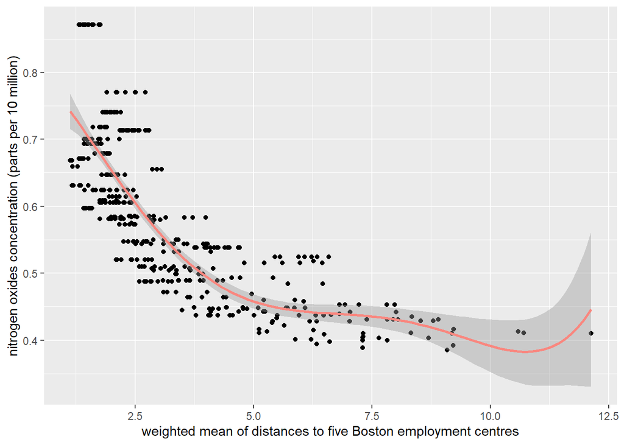

```r
ggplot(boston,
       aes(x = dis, y = nox)) +
          geom_point() +
          stat_smooth(method='lm', formula = y ~ poly(x,5), size = 1, colour = "#f9877f") +
          xlab('weighted mean of distances to five Boston employment centres') +
          ylab('nitrogen oxides concentration (parts per 10 million)')
```

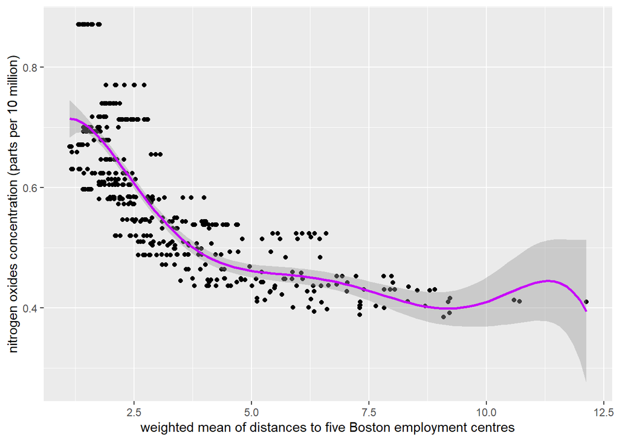

```r
ggplot(boston,
       aes(x = dis, y = nox)) +
          geom_point() +
          stat_smooth(method='lm', formula = y ~ poly(x,6), size = 1, colour = "#c808f9") +
          xlab('weighted mean of distances to five Boston employment centres') +
          ylab('nitrogen oxides concentration (parts per 10 million)')
```

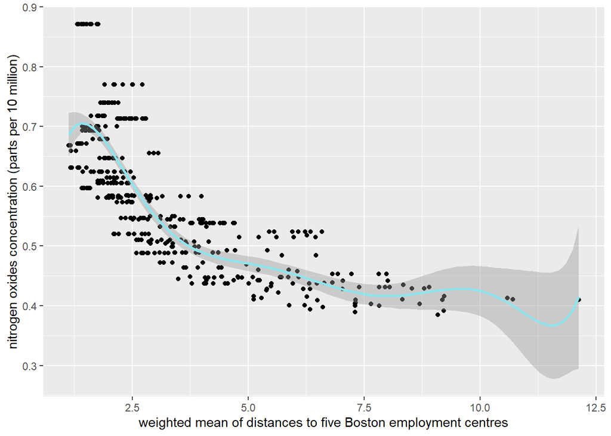

```r
ggplot(boston,
       aes(x = dis, y = nox)) +
          geom_point() +
          stat_smooth(method='lm', formula = y ~ poly(x,7), size = 1, colour = "#8ee5ee") +
          xlab('weighted mean of distances to five Boston employment centres') +
          ylab('nitrogen oxides concentration (parts per 10 million)')
```

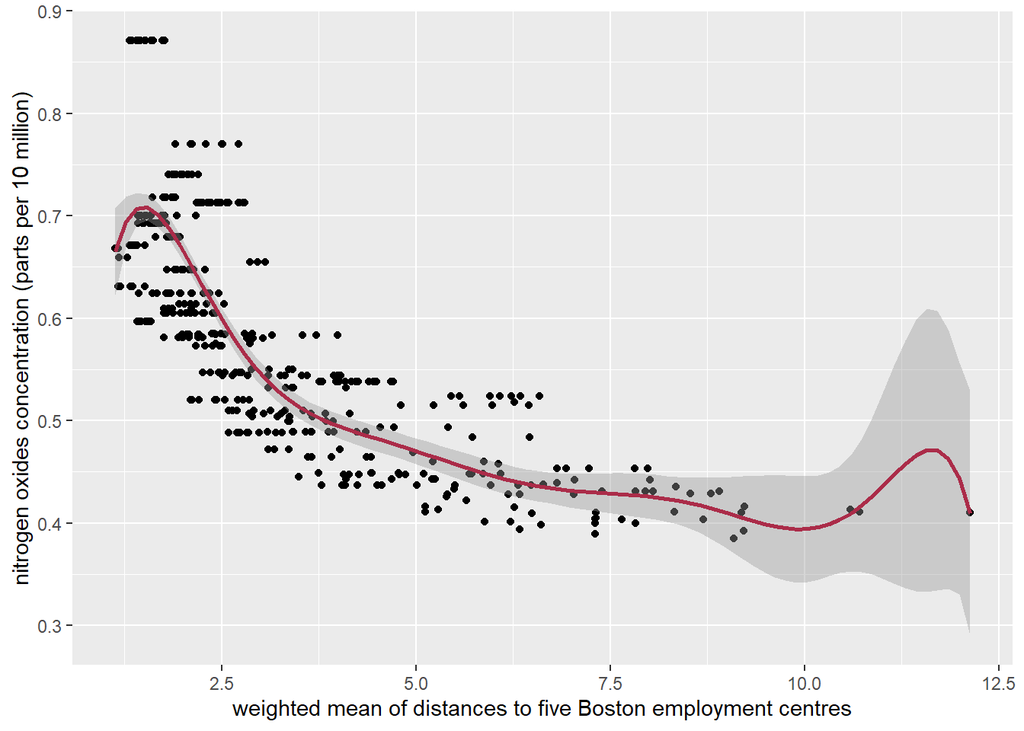

```r
ggplot(boston,
       aes(x = dis, y = nox)) +
          geom_point() +
          stat_smooth(method='lm', formula = y ~ poly(x,8), size = 1, colour = "#ab2c49") +
          xlab('weighted mean of distances to five Boston employment centres') +
          ylab('nitrogen oxides concentration (parts per 10 million)')
```

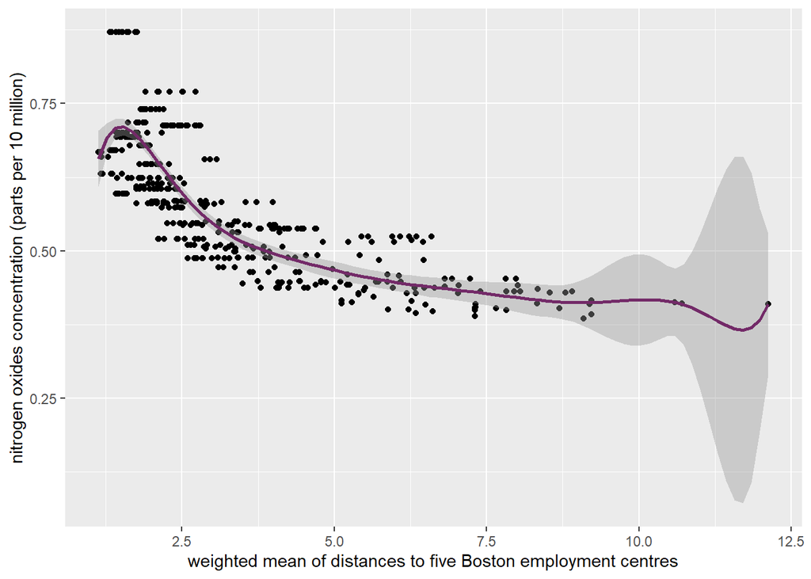

```r
ggplot(boston,
       aes(x = dis, y = nox)) +
          geom_point() +
          stat_smooth(method='lm', formula = y ~ poly(x,9), size = 1, colour = "#732a68") +
          xlab('weighted mean of distances to five Boston employment centres') +
          ylab('nitrogen oxides concentration (parts per 10 million)')
```

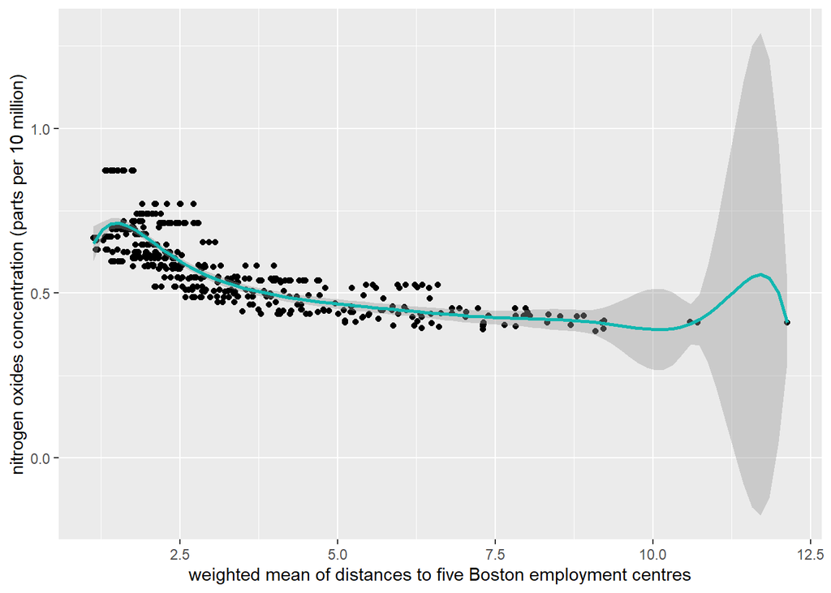

```r
ggplot(boston,
       aes(x = dis, y = nox)) +
          geom_point() +
          stat_smooth(method='lm', formula = y ~ poly(x,10), size = 1, colour = "#12b7b0") +
          xlab('weighted mean of distances to five Boston employment centres') +
          ylab('nitrogen oxides concentration (parts per 10 million)')
```

We can now calculate the RSS for these models:

```r
for (i in 1:10) {
  print(paste0("RSS for polynomial of degree ",i,":"))
  print(RSS((lm(nox ~ poly(dis, i), data = boston))))
}
```

```
## [1] "RSS for polynomial of degree 1:"
## [1] 2.768563
## [1] "RSS for polynomial of degree 2:"
## [1] 2.035262
## [1] "RSS for polynomial of degree 3:"
## [1] 1.934107
## [1] "RSS for polynomial of degree 4:"
## [1] 1.932981
## [1] "RSS for polynomial of degree 5:"
## [1] 1.91529
## [1] "RSS for polynomial of degree 6:"
## [1] 1.878257
## [1] "RSS for polynomial of degree 7:"
## [1] 1.849484
## [1] "RSS for polynomial of degree 8:"
## [1] 1.83563
## [1] "RSS for polynomial of degree 9:"
## [1] 1.833331
## [1] "RSS for polynomial of degree 10:"
## [1] 1.832171
```

### c

Perform cross-validation or another approach to select the optimal degree for the polynomial, and explain your results.

This code is adapted from Gavin Simpson’s code:

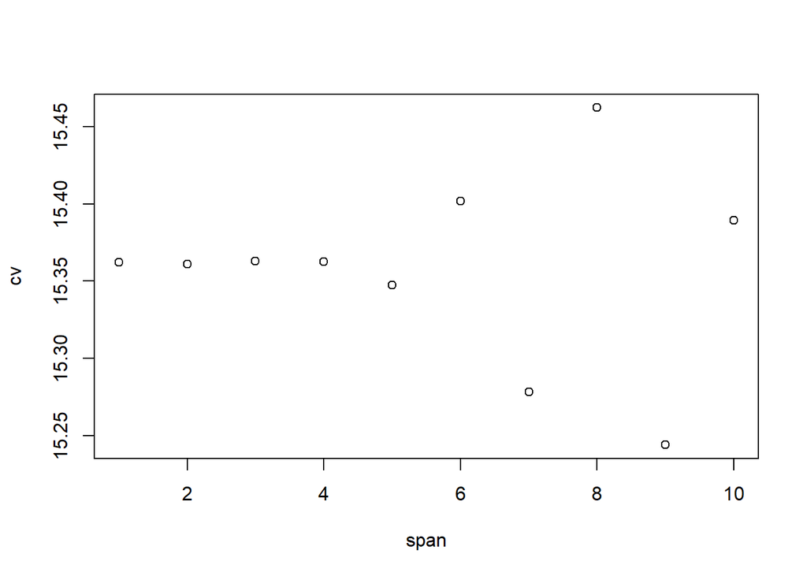

```r
k <- 10

#Create a vector of length 506 with values from 1-10 denoting which fold that observation is part of:
fold <- sample(k, nrow(boston), replace = TRUE)

#For each span from 1 to 10 we can calculate the cross-validated test error:
mse <- numeric(k)
span <- seq(1, 10, by = 1)
cv <- numeric(length(span))

for (j in seq_along(span))
{
  for (i in seq_len(k))
  {
    take <- fold == i
    foldi <- boston[take, ]
    foldOther <- boston[!take, ]
#   f <- loess(nox ~ dis, data=foldOther, span=span[j])
    f <- lm(nox ~ poly(dis, j), data = foldOther)
    pred <- predict(f, foldi)
    mse[i] <- mean((pred - foldi$dis)^2, na.rm = TRUE)
  }
  cv[j]<- mean(mse)
}

plot(span, cv)
```

Cross validation suggests that average test set MSE is similar for each degree of the polynomial, with odd values performing better, and polynomials of degree 7 and 9 minimizing average test set MSE, and thus performing best.

### d

Use the bs() function to fit a regression spline to predict nox using dis. Report the output for the fit using four degrees of freedom. How did you choose the knots? Plot the resulting fit.

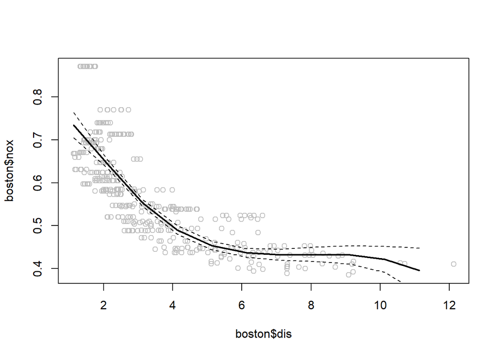

```r
boston.bs0 <- lm(nox ~ bs(dis, df = 4), data = boston)
dislims <- range(boston$dis)
dis.grid <- seq(from = dislims[1], to = dislims[2])
pred <- predict(boston.bs0 , newdata = list(dis = dis.grid), se = T)
plot (boston$dis, boston$nox, col = " gray ")
lines(dis.grid, pred$fit , lwd = 2)
lines(dis.grid, pred$fit + 2*pred$se, lty = "dashed")
lines(dis.grid, pred$fit - 2*pred$se, lty = "dashed")
```

### e

Now fit a regression spline for a range of degrees of freedom, and plot the resulting fits and report the resulting RSS. Describe the results obtained.

```r
for (i in 4:20) {
  print(paste0("RSS for spline of degree ",i,":"))
  print(RSS((lm(nox ~ bs(dis, df = i), data = boston))))
}
```

```
## [1] "RSS for spline of degree 4:"
## [1] 1.922775
## [1] "RSS for spline of degree 5:"
## [1] 1.840173
## [1] "RSS for spline of degree 6:"
## [1] 1.833966
## [1] "RSS for spline of degree 7:"
## [1] 1.829884
## [1] "RSS for spline of degree 8:"
## [1] 1.816995
## [1] "RSS for spline of degree 9:"
## [1] 1.825653
## [1] "RSS for spline of degree 10:"
## [1] 1.792535
## [1] "RSS for spline of degree 11:"
```

[output cut: 19 more lines]

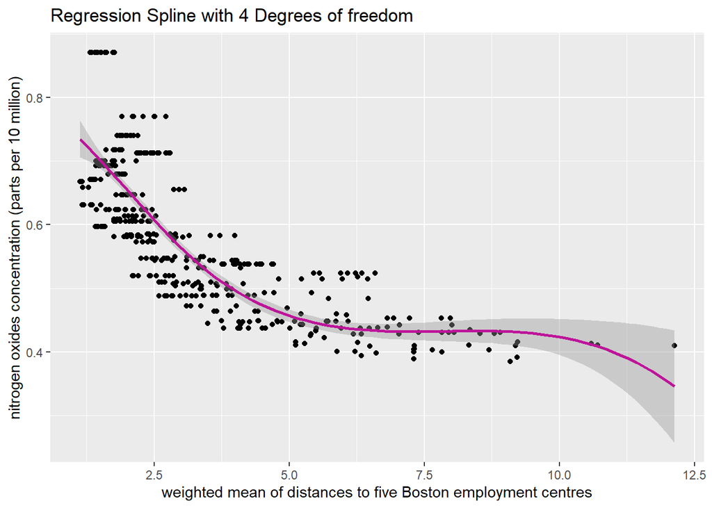

```r
ggplot(boston,
       aes(x = dis, y = nox)) +
          geom_point() +
          stat_smooth(method='lm', formula = y ~ bs(x, df = 4), size = 1, colour = "#be149a") +
          xlab('weighted mean of distances to five Boston employment centres') +
          ylab('nitrogen oxides concentration (parts per 10 million)') +
          ggtitle('Regression Spline with 4 Degrees of freedom')
```

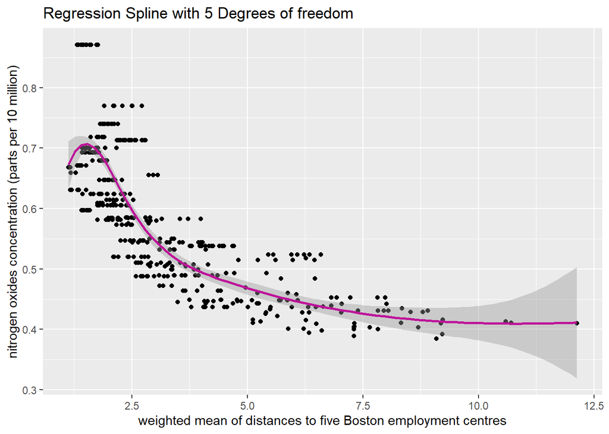

```r
ggplot(boston,
       aes(x = dis, y = nox)) +
          geom_point() +
          stat_smooth(method='lm', formula = y ~ bs(x, df = 5), size = 1, colour = "#be149a") +
          xlab('weighted mean of distances to five Boston employment centres') +
          ylab('nitrogen oxides concentration (parts per 10 million)') +
          ggtitle('Regression Spline with 5 Degrees of freedom')
```

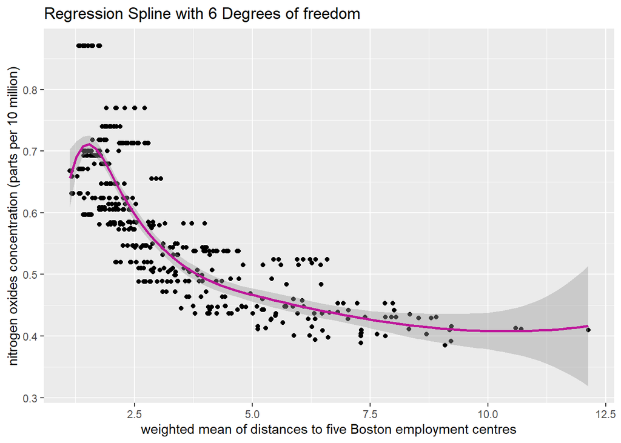

```r
ggplot(boston,
       aes(x = dis, y = nox)) +
          geom_point() +
          stat_smooth(method='lm', formula = y ~ bs(x, df = 6), size = 1, colour = "#be169a") +
          xlab('weighted mean of distances to five Boston employment centres') +
          ylab('nitrogen oxides concentration (parts per 10 million)') +
          ggtitle('Regression Spline with 6 Degrees of freedom')
```

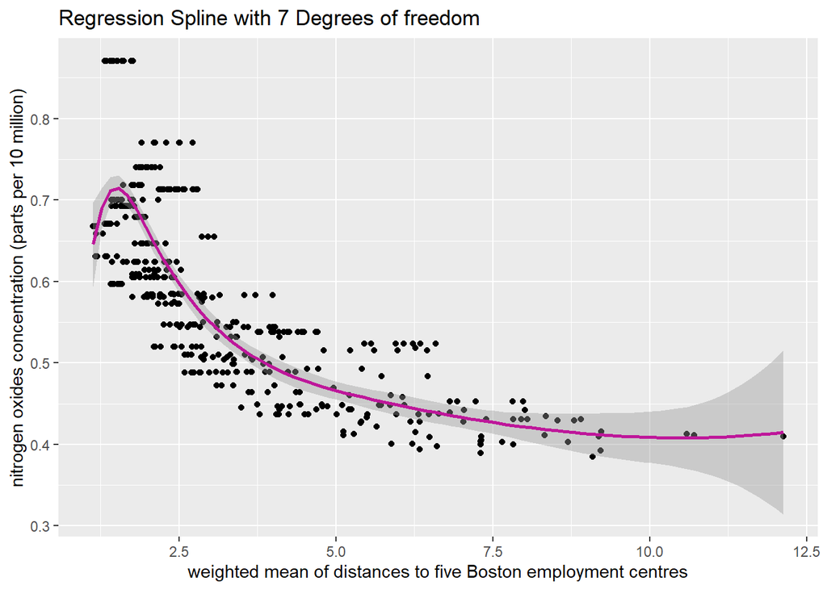

```r
ggplot(boston,
       aes(x = dis, y = nox)) +
          geom_point() +
          stat_smooth(method='lm', formula = y ~ bs(x, df = 7), size = 1, colour = "#be179a") +
          xlab('weighted mean of distances to five Boston employment centres') +
          ylab('nitrogen oxides concentration (parts per 10 million)') +
          ggtitle('Regression Spline with 7 Degrees of freedom')
```

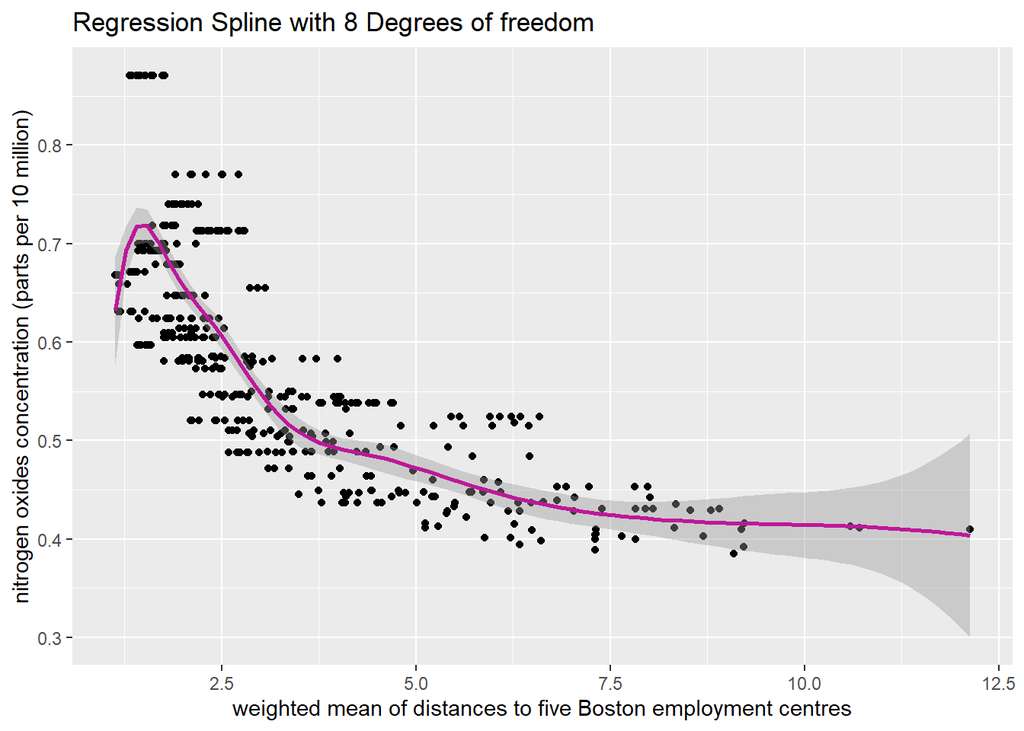

```r
ggplot(boston,
       aes(x = dis, y = nox)) +
          geom_point() +
          stat_smooth(method='lm', formula = y ~ bs(x, df = 8), size = 1, colour = "#be189a") +
          xlab('weighted mean of distances to five Boston employment centres') +
          ylab('nitrogen oxides concentration (parts per 10 million)') +
          ggtitle('Regression Spline with 8 Degrees of freedom')
```

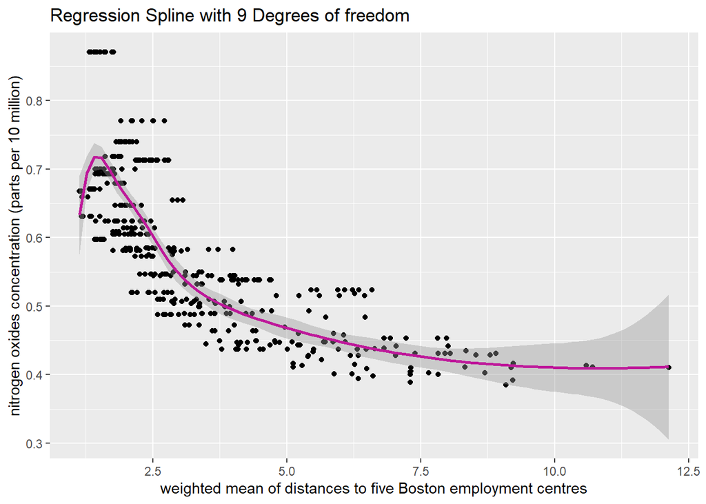

```r
ggplot(boston,
       aes(x = dis, y = nox)) +
          geom_point() +
          stat_smooth(method='lm', formula = y ~ bs(x, df = 9), size = 1, colour = "#be199a") +
          xlab('weighted mean of distances to five Boston employment centres') +
          ylab('nitrogen oxides concentration (parts per 10 million)') +
          ggtitle('Regression Spline with 9 Degrees of freedom')
```

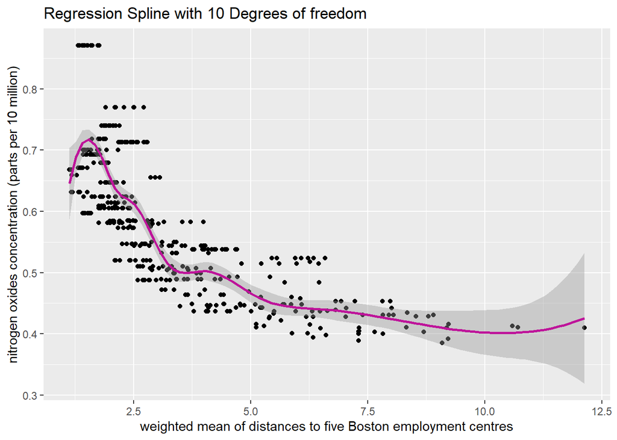

```r
ggplot(boston,
       aes(x = dis, y = nox)) +
          geom_point() +
          stat_smooth(method='lm', formula = y ~ bs(x, df = 10), size = 1, colour = "#be149a") +
          xlab('weighted mean of distances to five Boston employment centres') +
          ylab('nitrogen oxides concentration (parts per 10 million)') +
          ggtitle('Regression Spline with 10 Degrees of freedom')
```

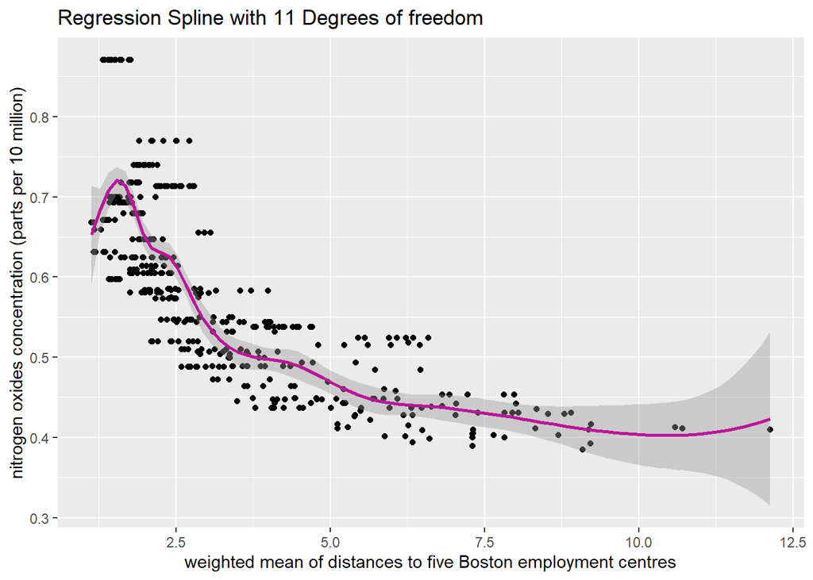

```r
ggplot(boston,
       aes(x = dis, y = nox)) +
          geom_point() +
          stat_smooth(method='lm', formula = y ~ bs(x, df = 11), size = 1, colour = "#be149a") +
          xlab('weighted mean of distances to five Boston employment centres') +
          ylab('nitrogen oxides concentration (parts per 10 million)') +
          ggtitle('Regression Spline with 11 Degrees of freedom')
```

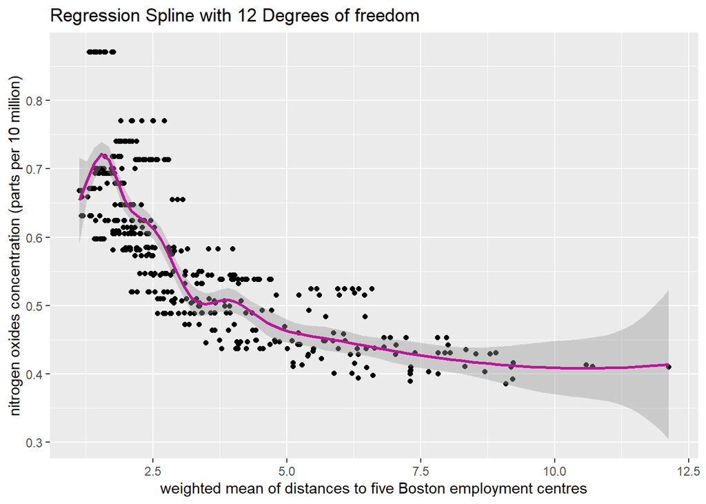

```r
ggplot(boston,
       aes(x = dis, y = nox)) +
          geom_point() +
          stat_smooth(method='lm', formula = y ~ bs(x, df = 12), size = 1, colour = "#be149a") +
          xlab('weighted mean of distances to five Boston employment centres') +
          ylab('nitrogen oxides concentration (parts per 10 million)') +
          ggtitle('Regression Spline with 12 Degrees of freedom')
```

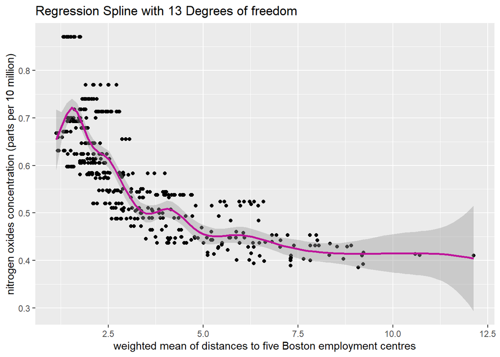

```r
ggplot(boston,
       aes(x = dis, y = nox)) +
          geom_point() +
          stat_smooth(method='lm', formula = y ~ bs(x, df = 13), size = 1, colour = "#be149a") +
          xlab('weighted mean of distances to five Boston employment centres') +
          ylab('nitrogen oxides concentration (parts per 10 million)') +
          ggtitle('Regression Spline with 13 Degrees of freedom')
```

Beyond 5 degrees of freedom the splines look quite similar, and have similar RSS values.

### f

Perform cross-validation or another approach in order to select the best degrees of freedom for a regression spline on this data. Describe your results.

We can again borrow and adapt the cross validation code from Gavin Simpson:

```r
k <- 10

#Create a vector of length 506 with values from 1-10 denoting which fold that observation is part of:
fold <- sample(k, nrow(boston), replace = TRUE)

#For each DOF from 4 to 20 we can calculate the cross-validated test error:
mse <- numeric(k)
DOF <- seq(4, 20, by = 1)
cv <- numeric(length(DOF))

for (j in seq_along(DOF))
{
  for (i in seq_len(k))
  {
    take <- fold == i
    foldi <- boston[take, ]
    foldOther <- boston[!take, ]
#   f <- loess(nox ~ dis, data=foldOther, span=span[j])
    f <- lm(nox ~ bs(dis, df = j), data = foldOther)
    pred <- predict(f, foldi)
    mse[i] <- mean((pred - foldi$dis)^2, na.rm = TRUE)
  }
  cv[j]<- mean(mse)
}
```

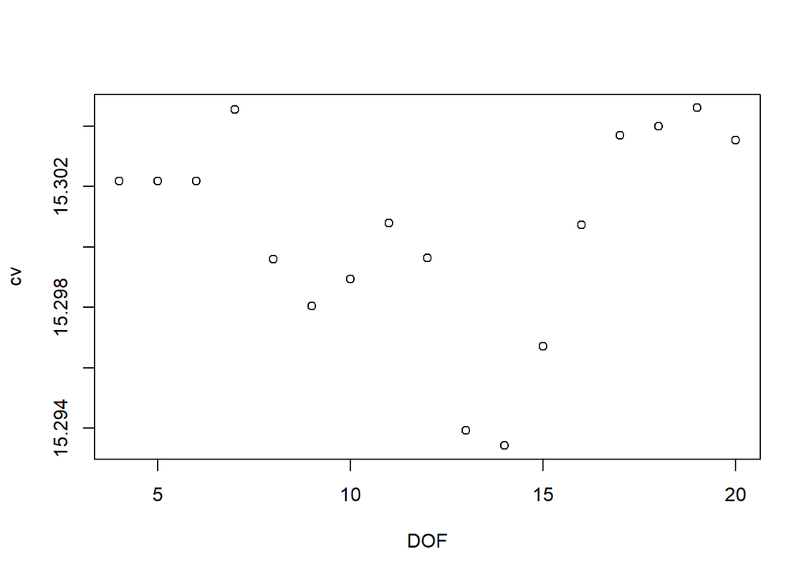

```r
plot(DOF, cv)
```

# Part D

QR exercise * Reproduce Fig 7.10. * quantile regression of a quadratic function for tau = 0.10, 0.50, 0.90. * Add the fitted quantile regression lines to the plot.

## Data

```r
wage <- Wage
```

## Figure 7.10

Unfortunately I could not get both local linear regressions onto the same ggplot:

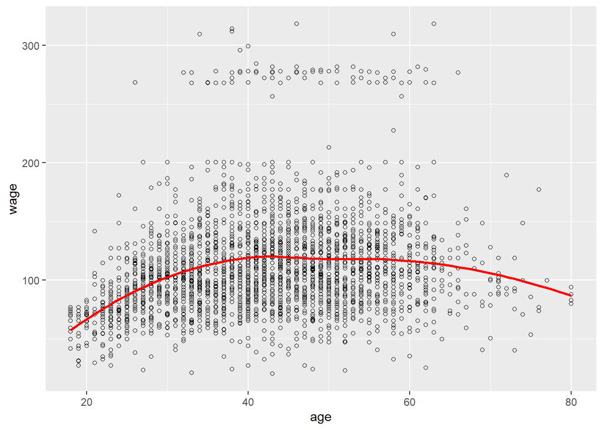

```r
ggplot(wage,
       aes(x = age, y = wage)) +
          geom_point(shape = 1) +
          # stat_smooth(method=stats::loess, formula = y ~ x, size = 1, span = 0.7, color = 'blue', se = FALSE) +
          stat_smooth(method=stats::loess, formula = y ~ x, size = 1, span = 0.2, color = 'red', se = FALSE) +
          xlab('age') +
          ylab('wage')
```

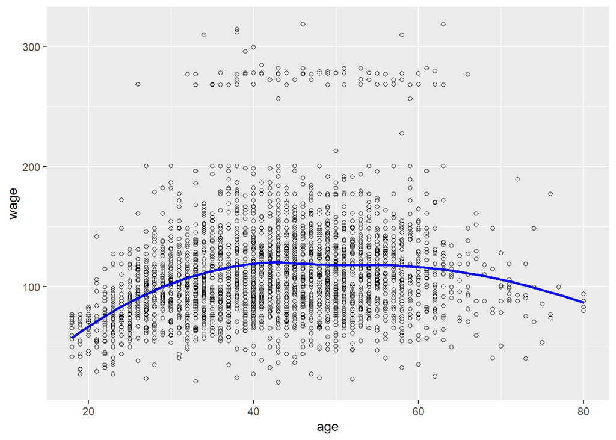

```r
ggplot(wage,
       aes(x = age, y = wage)) +
          geom_point(shape = 1) +
          stat_smooth(method=stats::loess, formula = y ~ x, size = 1, span = 0.7, color = 'blue', se = FALSE) +
          # stat_smooth(method=stats::loess, formula = y ~ x, size = 1, span = 0.2, color = 'red', se = FALSE) +
          xlab('age') +
          ylab('wage')
```

## Quantile regression

```r
wage.rq0 = rq(wage ~ age,
    tau = c(0.10, 0.5,0.90),
    data = wage,
    na.action = na.omit,
    model = TRUE)
summary(wage.rq0)
```

```
##
## Call: rq(formula = wage ~ age, tau = c(0.1, 0.5, 0.9), data = wage,
##     na.action = na.omit, model = TRUE)
##
## tau: [1] 0.1
##
## Coefficients:
##             Value    Std. Error t value  Pr(>|t|)
## (Intercept) 54.74560  2.81671   19.43602  0.00000
## age          0.38378  0.06646    5.77501  0.00000
##
## Call: rq(formula = wage ~ age, tau = c(0.1, 0.5, 0.9), data = wage,
##     na.action = na.omit, model = TRUE)
##
## tau: [1] 0.5
##
## Coefficients:
##             Value    Std. Error t value  Pr(>|t|)
## (Intercept) 75.78037  2.73397   27.71807  0.00000
## age          0.70355  0.06436   10.93233  0.00000
##
## Call: rq(formula = wage ~ age, tau = c(0.1, 0.5, 0.9), data = wage,
##     na.action = na.omit, model = TRUE)
##
## tau: [1] 0.9
##
## Coefficients:
##             Value     Std. Error t value   Pr(>|t|)
## (Intercept) 102.04207   5.21024   19.58490   0.00000
## age           1.26769   0.14445    8.77616   0.00000
```

```r
summary(wage.rq0, se="boot")
```

```
##
## Call: rq(formula = wage ~ age, tau = c(0.1, 0.5, 0.9), data = wage,
##     na.action = na.omit, model = TRUE)
##
## tau: [1] 0.1
##
## Coefficients:
##             Value    Std. Error t value  Pr(>|t|)
## (Intercept) 54.74560  2.40514   22.76188  0.00000
## age          0.38378  0.05699    6.73484  0.00000
##
## Call: rq(formula = wage ~ age, tau = c(0.1, 0.5, 0.9), data = wage,
##     na.action = na.omit, model = TRUE)
##
## tau: [1] 0.5
##
## Coefficients:
##             Value    Std. Error t value  Pr(>|t|)
## (Intercept) 75.78037  2.88141   26.29975  0.00000
## age          0.70355  0.06803   10.34127  0.00000
##
## Call: rq(formula = wage ~ age, tau = c(0.1, 0.5, 0.9), data = wage,
##     na.action = na.omit, model = TRUE)
##
## tau: [1] 0.9
##
## Coefficients:
##             Value     Std. Error t value   Pr(>|t|)
## (Intercept) 102.04207   8.47649   12.03825   0.00000
## age           1.26769   0.21963    5.77194   0.00000
```

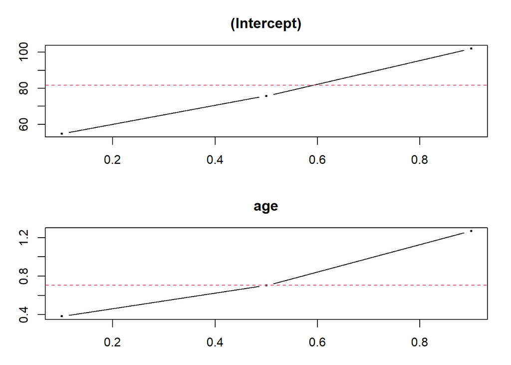

```r
plot(wage.rq0)
```

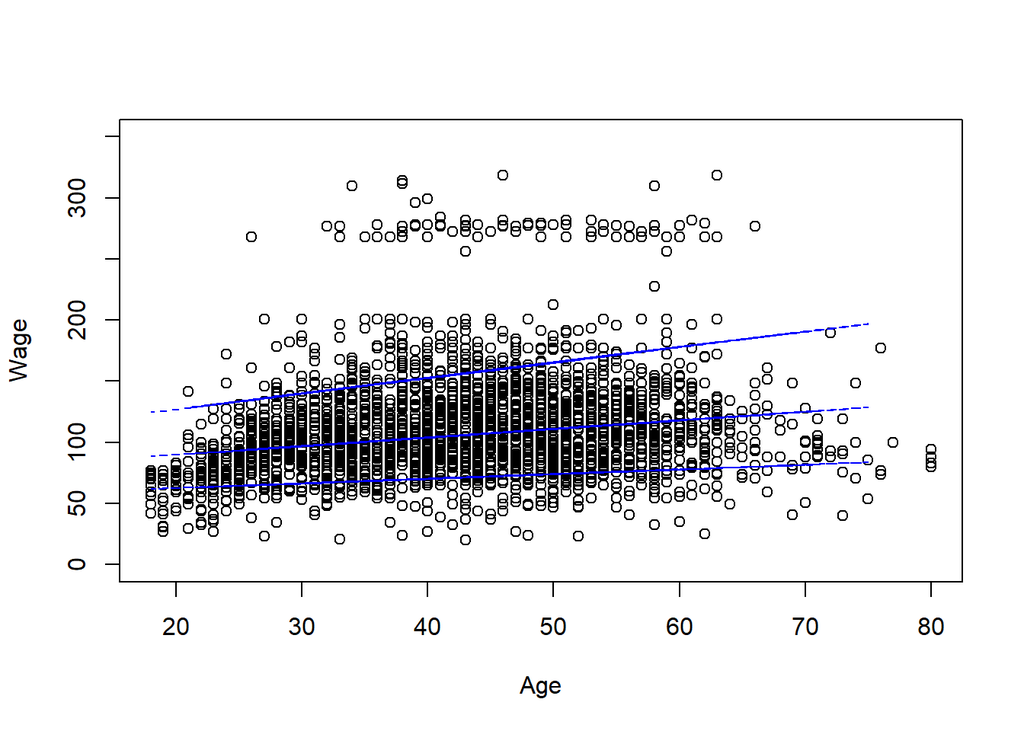

```r
plot(c(18,80),c(0,350),type="n", xlab="Age",ylab="Wage")
points(wage$age,wage$wage,col="black")
for(i in c(1,2,3))lines(wage.rq0$x[18:80,2],wage.rq0$fit[18:80,i],col="blue",lty=2)
```

```r
# lines(m1.s1$x[1:16,2],m1.s1$fit[1:16,3],col="blue",lwd=2)
```

# References

1. Xue X, Xie X, Strickler HD. A censored quantile regression approach for the analysis of time to event data. Stat Methods Med Res. 2018;27(3):955-965. doi:10.1177/0962280216648724
2. James G, Witten D, Hastie T, Tibshirani R. An Introduction to Statistical Learning: With Applications in R. 1st ed. 2013, Corr. 7th printing 2017 edition. Springer; 2013.